# Assignment2

## Result

It is found that the model accuracy of **Logistic Regression** is **94%**.

This means the model gives correct result 94% of the time.

### **KNN Classifier**

```python
bank.groupby(["Personal Loan"]).count()
```

| Personal Loan | Age | Experience | Income | Family | CCAvg | Education | Mortgage | Securities Account | CD Account | Online | CreditCard |
| --- | --- | --- | --- | --- | --- | --- | --- | --- | --- | --- | --- |
| 0 | 4520 | 4520 | 4520 | 4520 | 4520 | 4520 | 4520 | 4520 | 4520 | 4520 | 4520 |
| 1 | 480 | 480 | 480 | 480 | 480 | 480 | 480 | 480 | 480 | 480 | 480 |

```python
XScaled  = X.apply(zscore)
XScaled.describe()
```

|  | Age | Experience | Income | Family | CCAvg | Education | Mortgage | Securities Account | CD Account | Online | CreditCard |
| --- | --- | --- | --- | --- | --- | --- | --- | --- | --- | --- | --- |
| count | 5.000000e+03 | 5.000000e+03 | 5.000000e+03 | 5.000000e+03 | 5.000000e+03 | 5.000000e+03 | 5.000000e+03 | 5.000000e+03 | 5.000000e+03 | 5.000000e+03 | 5.000000e+03 |
| mean | 2.478018e-17 | -1.693312e-16 | 1.939449e-16 | 7.850609e-16 | -2.078338e-17 | -6.315837e-16 | 2.810197e-16 | 5.092149e-16 | 4.426903e-16 | 2.986500e-16 | -3.697931e-16 |
| std | 1.000100e+00 | 1.000100e+00 | 1.000100e+00 | 1.000100e+00 | 1.000100e+00 | 1.000100e+00 | 1.000100e+00 | 1.000100e+00 | 1.000100e+00 | 1.000100e+00 | 1.000100e+00 |
| min | -1.948906e+00 | -2.014911e+00 | -1.428969e+00 | -1.216855e+00 | -1.108987e+00 | -1.049078e+00 | -5.555239e-01 | -3.414233e-01 | -2.535403e-01 | -1.216618e+00 | -6.453143e-01 |
| 25% | -9.019702e-01 | -8.812043e-01 | -7.554825e-01 | -1.216855e+00 | -7.084116e-01 | -1.049078e+00 | -5.555239e-01 | -3.414233e-01 | -2.535403e-01 | -1.216618e+00 | -6.453143e-01 |
| 50% | -2.952359e-02 | -9.121982e-03 | -2.123482e-01 | -3.454321e-01 | -2.506106e-01 | 1.417029e-01 | -5.555239e-01 | -3.414233e-01 | -2.535403e-01 | 8.219509e-01 | -6.453143e-01 |
| 75% | 8.429230e-01 | 8.629604e-01 | 5.263146e-01 | 5.259909e-01 | 3.216407e-01 | 1.332484e+00 | 4.375576e-01 | -3.414233e-01 | -2.535403e-01 | 8.219509e-01 | 1.549632e+00 |
| max | 1.889859e+00 | 1.996667e+00 | 3.263712e+00 | 1.397414e+00 | 4.613525e+00 | 1.332484e+00 | 5.688108e+00 | 2.928915e+00 | 3.944146e+00 | 8.219509e-01 | 1.549632e+00 |

```python
X_train, X_test, y_train, y_test = train_test_split(XScaled, Y, test_size=0.30, random_state=42)
```

```python
NNH = KNeighborsClassifier(n_neighbors= 5 , weights = 'distance' )
```

```python
NNH.fit(X_train, y_train)
```

```
KNeighborsClassifier(algorithm='auto', leaf_size=30, metric='minkowski',
                     metric_params=None, n_jobs=None, n_neighbors=5, p=2,
                     weights='distance')
```

```python
predicted_labels = NNH.predict(X_test)
NNH.score(X_test, y_test)
```

```
0.96
```

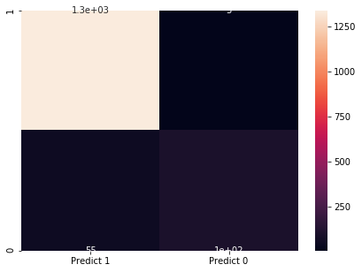

```python
knnm=metrics.confusion_matrix(y_test, predicted_labels)
knn_m = pd.DataFrame(knnm, index = [i for i in ["1","0"]],columns = [i for i in ["Predict 1","Predict 0"]])
plt.figure(figsize = (7,5))
sns.heatmap(knn_m, annot=True)
```

```python
print("Classification Report")
print(metrics.classification_report(y_test, predicted_labels, labels=[1, 0]))
```

```
Classification Report
              precision    recall  f1-score   support

           1       0.95      0.65      0.77       157
           0       0.96      1.00      0.98      1343

    accuracy                           0.96      1500
   macro avg       0.96      0.82      0.88      1500
weighted avg       0.96      0.96      0.96      1500
```

## Result

The model accuracy of **KNN Classifier** is **96%**.

## **Naive Bayes classifier**

```python
X = bank.drop('Personal Loan',axis=1)
Y = bank['Personal Loan']
x_train, x_test, y_train, y_test = train_test_split(X, Y, test_size=0.3, random_state=42)
x_train.head()
```

|  | Age | Experience | Income | Family | CCAvg | Education | Mortgage | Securities Account | CD Account | Online | CreditCard |
| --- | --- | --- | --- | --- | --- | --- | --- | --- | --- | --- | --- |
| 1840 | 55 | 25 | 23 | 4 | 0.4 | 3 | 88 | 0 | 0 | 0 | 0 |
| 2115 | 57 | 31 | 30 | 3 | 1.4 | 1 | 0 | 0 | 0 | 0 | 0 |
| 4437 | 63 | 38 | 63 | 2 | 1.5 | 1 | 0 | 0 | 0 | 1 | 0 |
| 1146 | 31 | 7 | 71 | 1 | 0.1 | 1 | 78 | 1 | 0 | 0 | 0 |
| 2486 | 61 | 36 | 130 | 1 | 1.3 | 1 | 257 | 0 | 0 | 0 | 0 |

```python
bank_model = GaussianNB()
bank_model.fit(x_train, y_train.ravel())
```

```
GaussianNB(priors=None, var_smoothing=1e-09)
```

```python
bank_train_predict = bank_model.predict(x_train)
print("Model Accuracy: ",(metrics.accuracy_score(y_train, bank_train_predict)))
print()
```

```
Model Accuracy:  0.8825714285714286
```

```python
bank_test_predict = bank_model.predict(x_test)
print("Model Accuracy:",(metrics.accuracy_score(y_test,bank_test_predict)))
print()
```

```
Model Accuracy: 0.892
```

```
Confusion Matrix
```

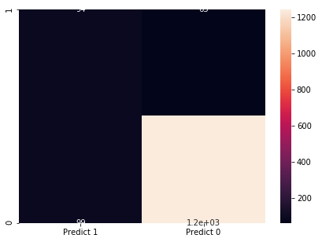

```python
print("Confusion Matrix")
nbtm=metrics.confusion_matrix(y_test, bank_test_predict, labels=[1,0])

nbt_m = pd.DataFrame(nbtm, index = [i for i in ["1","0"]],
                  columns = [i for i in ["Predict 1","Predict 0"]])
plt.figure(figsize = (7,5))
sns.heatmap(nbt_m, annot=True)
```

```python
print("Classification Report")
print(metrics.classification_report(y_test, bank_test_predict, labels=[1, 0]))
```

```
Classification Report
              precision    recall  f1-score   support

           1       0.49      0.60      0.54       157
           0       0.95      0.93      0.94      1343

    accuracy                           0.89      1500
   macro avg       0.72      0.76      0.74      1500
weighted avg       0.90      0.89      0.90      1500
```

## Confusion matrix of models

```python
print("Confusion matrix of logistic regression")
print("")
print(lr_m)
print("")
print("Confusion matrix of KNN Clasifier")
print("")
print(knn_m)
print("")
print("Confusion matrix of Naive Bayes Theorem")
print("")
print(nbt_m)
print("")
```

```
Confusion matrix of logistic regression

   Predict 1  Predict 0
1       1321         22
0         70         87

Confusion matrix of KNN Clasifier

   Predict 1  Predict 0
1       1338          5
0         55        102

Confusion matrix of Naive Bayes Theorem

   Predict 1  Predict 0
1         94         63
0         99       1244
```

## Result

The model accuracy of **Naive Bayes classifier** is **89**.

This means model gives correct result 89% of the time.

# From the above model of Logistic regression, KNN, and Naive bayes.

- It is found out that the best model is KNN. As we can see that the\

  accuracy is 96 and the weighted average of recall is 96 which is more than\

  the other two models.

## Reason for KNN being the best model.

- It doesn't make a prior assumption like naive bayes theorem.
- In logistic regression, assumption of linearity is used thus some

  points may be away from the line where as in KNN distance from nearby

  points are calculated thus more accuracy can be gained.